# **Problem Statement**

#### **Business Context**

Understanding customer personality and behavior is pivotal for businesses to enhance customer satisfaction and increase revenue. Segmentation based on a customer's personality, demographics, and purchasing behavior allows companies to create tailored marketing campaigns, improve customer retention, and optimize product offerings.

A leading retail company with a rapidly growing customer base seeks to gain deeper insights into their customers' profiles. The company recognizes that understanding customer personalities, lifestyles, and purchasing habits can unlock significant opportunities for personalizing marketing strategies and creating loyalty programs. These insights can help address critical business challenges, such as improving the effectiveness of marketing campaigns, identifying high-value customer groups, and fostering long-term relationships with customers.

With the competition intensifying in the retail space, moving away from generic strategies to more targeted and personalized approaches is essential for sustaining a competitive edge.

#### **Objective**

In an effort to optimize marketing efficiency and enhance customer experience, the company has embarked on a mission to identify distinct customer segments. By understanding the characteristics, preferences, and behaviors of each group, the company aims to:

1. Develop personalized marketing campaigns to increase conversion rates.
2. Create effective retention strategies for high-value customers.
3. Optimize resource allocation, such as inventory management, pricing strategies, and store layouts.

As a data scientist tasked with this project, your responsibility is to analyze the given customer data, apply machine learning techniques to segment the customer base, and provide actionable insights into the characteristics of each segment.

#### **Data Dictionary**

The dataset includes historical data on customer demographics, personality traits, and purchasing behaviors. Key attributes are:

1. **Customer Information**
   - **ID:** Unique identifier for each customer.
   - **Year_Birth:** Customer's year of birth.
   - **Education:** Education level of the customer.
   - **Marital_Status:** Marital status of the customer.
   - **Income:** Yearly household income (in dollars).
   - **Kidhome:** Number of children in the household.
   - **Teenhome:** Number of teenagers in the household.
   - **Dt_Customer:** Date when the customer enrolled with the company.
   - **Recency:** Number of days since the customer’s last purchase.
   - **Complain:** Whether the customer complained in the last 2 years (1 for yes, 0 for no).
2. **Spending Information (Last 2 Years)**
   - **MntWines:** Amount spent on wine.
   - **MntFruits:** Amount spent on fruits.
   - **MntMeatProducts:** Amount spent on meat.
   - **MntFishProducts:** Amount spent on fish.
   - **MntSweetProducts:** Amount spent on sweets.
   - **MntGoldProds:** Amount spent on gold products.
3. **Purchase and Campaign Interaction**
   - **NumDealsPurchases:** Number of purchases made using a discount.
   - **AcceptedCmp1:** Response to the 1st campaign (1 for yes, 0 for no).
   - **AcceptedCmp2:** Response to the 2nd campaign (1 for yes, 0 for no).
   - **AcceptedCmp3:** Response to the 3rd campaign (1 for yes, 0 for no).
   - **AcceptedCmp4:** Response to the 4th campaign (1 for yes, 0 for no).
   - **AcceptedCmp5:** Response to the 5th campaign (1 for yes, 0 for no).
   - **Response:** Response to the last campaign (1 for yes, 0 for no).
4. **Shopping Behavior**
   - **NumWebPurchases:** Number of purchases made through the company’s website.
   - **NumCatalogPurchases:** Number of purchases made using catalogs.
   - **NumStorePurchases:** Number of purchases made directly in stores.
   - **NumWebVisitsMonth:** Number of visits to the company’s website in the last month.

# **Let's start coding!**

## **Importing necessary libraries**

```python
# Libraries to help with reading and manipulating data
import pandas as pd
import numpy as np

# libaries to help with data visualization
import matplotlib.pyplot as plt
import seaborn as sns

# Removes the limit for the number of displayed columns
pd.set_option("display.max_columns", None)
# Sets the limit for the number of displayed rows
pd.set_option("display.max_rows", 200)

# to scale the data using z-score
from sklearn.preprocessing import StandardScaler

# to compute distances
from scipy.spatial.distance import cdist, pdist

# to perform k-means clustering and compute silhouette scores
from sklearn.cluster import KMeans
from sklearn.metrics import silhouette_score

# to visualize the elbow curve and silhouette scores
from yellowbrick.cluster import KElbowVisualizer, SilhouetteVisualizer

# to suppress warnings
import warnings

warnings.filterwarnings("ignore")
```

## **Loading the data**

```python
# uncomment and run the following line if using Google Colab
from google.colab import drive
drive.mount('/content/drive')
```

```python
# loading data into a pandas dataframe
data = pd.read_csv("/content/drive/MyDrive/Data Science Coursework/Project 1/Customer_Personality_Segmentation.csv", sep="\t")
```

## **Data Overview**

#### **Question 1**: What are the data types of all the columns?

```python
#get an idea of how many rows and columns we are working with
data.shape
```

```
(2240, 29)
```

```python
# Write your code here.
#code to get a brief look at a handful of the data in the dataset
data.head()
```

|  | ID | Year_Birth | Education | Marital_Status | Income | Kidhome | Teenhome | Dt_Customer | Recency | MntWines | MntFruits | MntMeatProducts | MntFishProducts | MntSweetProducts | MntGoldProds | NumDealsPurchases | NumWebPurchases | NumCatalogPurchases | NumStorePurchases | NumWebVisitsMonth | AcceptedCmp3 | AcceptedCmp4 | AcceptedCmp5 | AcceptedCmp1 | AcceptedCmp2 | Complain | Z_CostContact | Z_Revenue | Response |
| --- | --- | --- | --- | --- | --- | --- | --- | --- | --- | --- | --- | --- | --- | --- | --- | --- | --- | --- | --- | --- | --- | --- | --- | --- | --- | --- | --- | --- | --- |
| 0 | 5524 | 1957 | Graduation | Single | 58138.0 | 0 | 0 | 04-09-2012 | 58 | 635 | 88 | 546 | 172 | 88 | 88 | 3 | 8 | 10 | 4 | 7 | 0 | 0 | 0 | 0 | 0 | 0 | 3 | 11 | 1 |
| 1 | 2174 | 1954 | Graduation | Single | 46344.0 | 1 | 1 | 08-03-2014 | 38 | 11 | 1 | 6 | 2 | 1 | 6 | 2 | 1 | 1 | 2 | 5 | 0 | 0 | 0 | 0 | 0 | 0 | 3 | 11 | 0 |
| 2 | 4141 | 1965 | Graduation | Together | 71613.0 | 0 | 0 | 21-08-2013 | 26 | 426 | 49 | 127 | 111 | 21 | 42 | 1 | 8 | 2 | 10 | 4 | 0 | 0 | 0 | 0 | 0 | 0 | 3 | 11 | 0 |
| 3 | 6182 | 1984 | Graduation | Together | 26646.0 | 1 | 0 | 10-02-2014 | 26 | 11 | 4 | 20 | 10 | 3 | 5 | 2 | 2 | 0 | 4 | 6 | 0 | 0 | 0 | 0 | 0 | 0 | 3 | 11 | 0 |
| 4 | 5324 | 1981 | PhD | Married | 58293.0 | 1 | 0 | 19-01-2014 | 94 | 173 | 43 | 118 | 46 | 27 | 15 | 5 | 5 | 3 | 6 | 5 | 0 | 0 | 0 | 0 | 0 | 0 | 3 | 11 | 0 |

Pretty extensive number of features (or columns) in the dataset

```python
#get info for each columns
data.info()
```

```
<class 'pandas.core.frame.DataFrame'>
RangeIndex: 2240 entries, 0 to 2239
Data columns (total 29 columns):
 #   Column               Non-Null Count  Dtype
---  ------               --------------  -----
 0   ID                   2240 non-null   int64
 1   Year_Birth           2240 non-null   int64
 2   Education            2240 non-null   object
 3   Marital_Status       2240 non-null   object
 4   Income               2216 non-null   float64
 5   Kidhome              2240 non-null   int64
 6   Teenhome             2240 non-null   int64
 7   Dt_Customer          2240 non-null   object
 8   Recency              2240 non-null   int64
 9   MntWines             2240 non-null   int64
```

[output cut: 21 more lines]

Majority of the columns are integers, income column appears to be a float and three object columns (Education, Marital_Status, Dt_Customer). From observation, Dt_Customer column should be adjusted to be a datetime datatype.

##### **Observations:** Change the datatype of Dt_Customer column and the income column appears to be missing some values (24 to be exact)

```python
#converting the Dt_Customer column to datetime format
data['Dt_Customer']  = pd.to_datetime(data['Dt_Customer'],dayfirst=True)
data.info()
```

```
<class 'pandas.core.frame.DataFrame'>
RangeIndex: 2240 entries, 0 to 2239
Data columns (total 29 columns):
 #   Column               Non-Null Count  Dtype
---  ------               --------------  -----
 0   ID                   2240 non-null   int64
 1   Year_Birth           2240 non-null   int64
 2   Education            2240 non-null   object
 3   Marital_Status       2240 non-null   object
 4   Income               2216 non-null   float64
 5   Kidhome              2240 non-null   int64
 6   Teenhome             2240 non-null   int64
 7   Dt_Customer          2240 non-null   datetime64[ns]
 8   Recency              2240 non-null   int64
 9   MntWines             2240 non-null   int64
```

[output cut: 21 more lines]

#### **Question 2:** Check the statistical summary of the data. What is the average household income?

```python
#code to get statistical summary of all data
data.describe().T
```

|  | count | mean | min | 25% | 50% | 75% | max | std |
| --- | --- | --- | --- | --- | --- | --- | --- | --- |
| ID | 2240.0 | 5592.159821 | 0.0 | 2828.25 | 5458.5 | 8427.75 | 11191.0 | 3246.662198 |
| Year_Birth | 2240.0 | 1968.805804 | 1893.0 | 1959.0 | 1970.0 | 1977.0 | 1996.0 | 11.984069 |
| Income | 2216.0 | 52247.251354 | 1730.0 | 35303.0 | 51381.5 | 68522.0 | 666666.0 | 25173.076661 |
| Kidhome | 2240.0 | 0.444196 | 0.0 | 0.0 | 0.0 | 1.0 | 2.0 | 0.538398 |
| Teenhome | 2240.0 | 0.50625 | 0.0 | 0.0 | 0.0 | 1.0 | 2.0 | 0.544538 |
| Dt_Customer | 2240 | 2013-07-10 10:01:42.857142784 | 2012-07-30 00:00:00 | 2013-01-16 00:00:00 | 2013-07-08 12:00:00 | 2013-12-30 06:00:00 | 2014-06-29 00:00:00 | NaN |
| Recency | 2240.0 | 49.109375 | 0.0 | 24.0 | 49.0 | 74.0 | 99.0 | 28.962453 |
| MntWines | 2240.0 | 303.935714 | 0.0 | 23.75 | 173.5 | 504.25 | 1493.0 | 336.597393 |
| MntFruits | 2240.0 | 26.302232 | 0.0 | 1.0 | 8.0 | 33.0 | 199.0 | 39.773434 |
| MntMeatProducts | 2240.0 | 166.95 | 0.0 | 16.0 | 67.0 | 232.0 | 1725.0 | 225.715373 |
| MntFishProducts | 2240.0 | 37.525446 | 0.0 | 3.0 | 12.0 | 50.0 | 259.0 | 54.628979 |
| MntSweetProducts | 2240.0 | 27.062946 | 0.0 | 1.0 | 8.0 | 33.0 | 263.0 | 41.280498 |
| MntGoldProds | 2240.0 | 44.021875 | 0.0 | 9.0 | 24.0 | 56.0 | 362.0 | 52.167439 |
| NumDealsPurchases | 2240.0 | 2.325 | 0.0 | 1.0 | 2.0 | 3.0 | 15.0 | 1.932238 |
| NumWebPurchases | 2240.0 | 4.084821 | 0.0 | 2.0 | 4.0 | 6.0 | 27.0 | 2.778714 |
| NumCatalogPurchases | 2240.0 | 2.662054 | 0.0 | 0.0 | 2.0 | 4.0 | 28.0 | 2.923101 |
| NumStorePurchases | 2240.0 | 5.790179 | 0.0 | 3.0 | 5.0 | 8.0 | 13.0 | 3.250958 |
| NumWebVisitsMonth | 2240.0 | 5.316518 | 0.0 | 3.0 | 6.0 | 7.0 | 20.0 | 2.426645 |
| AcceptedCmp3 | 2240.0 | 0.072768 | 0.0 | 0.0 | 0.0 | 0.0 | 1.0 | 0.259813 |
| AcceptedCmp4 | 2240.0 | 0.074554 | 0.0 | 0.0 | 0.0 | 0.0 | 1.0 | 0.262728 |
| AcceptedCmp5 | 2240.0 | 0.072768 | 0.0 | 0.0 | 0.0 | 0.0 | 1.0 | 0.259813 |
| AcceptedCmp1 | 2240.0 | 0.064286 | 0.0 | 0.0 | 0.0 | 0.0 | 1.0 | 0.245316 |
| AcceptedCmp2 | 2240.0 | 0.013393 | 0.0 | 0.0 | 0.0 | 0.0 | 1.0 | 0.114976 |
| Complain | 2240.0 | 0.009375 | 0.0 | 0.0 | 0.0 | 0.0 | 1.0 | 0.096391 |
| Z_CostContact | 2240.0 | 3.0 | 3.0 | 3.0 | 3.0 | 3.0 | 3.0 | 0.0 |
| Z_Revenue | 2240.0 | 11.0 | 11.0 | 11.0 | 11.0 | 11.0 | 11.0 | 0.0 |
| Response | 2240.0 | 0.149107 | 0.0 | 0.0 | 0.0 | 0.0 | 1.0 | 0.356274 |

##### **Observations:** The average household income appears to be 52247.25 (2 decimal places).

#### There seems to be a lot of outliers in the columns when comparing the means to the max value except in the survey question columns

#### **Question 3:** Are there any missing values in the data? If yes, treat them using an appropriate method

```python
#missing values for household income to be treated by replacing empty values
#find areas where the values are missing
data.info()
data.isnull().sum()  ##24 null values for 'Income' column
```

```
<class 'pandas.core.frame.DataFrame'>
RangeIndex: 2240 entries, 0 to 2239
Data columns (total 29 columns):
 #   Column               Non-Null Count  Dtype
---  ------               --------------  -----
 0   ID                   2240 non-null   int64
 1   Year_Birth           2240 non-null   int64
 2   Education            2240 non-null   object
 3   Marital_Status       2240 non-null   object
 4   Income               2216 non-null   float64
 5   Kidhome              2240 non-null   int64
 6   Teenhome             2240 non-null   int64
 7   Dt_Customer          2240 non-null   datetime64[ns]
 8   Recency              2240 non-null   int64
 9   MntWines             2240 non-null   int64
```

[output cut: 21 more lines]

|  | 0 |
| --- | --- |
| ID | 0 |
| Year_Birth | 0 |
| Education | 0 |
| Marital_Status | 0 |
| Income | 24 |
| Kidhome | 0 |
| Teenhome | 0 |
| Dt_Customer | 0 |
| Recency | 0 |
| MntWines | 0 |
| MntFruits | 0 |
| MntMeatProducts | 0 |
| MntFishProducts | 0 |
| MntSweetProducts | 0 |
| MntGoldProds | 0 |
| NumDealsPurchases | 0 |
| NumWebPurchases | 0 |
| NumCatalogPurchases | 0 |
| NumStorePurchases | 0 |
| NumWebVisitsMonth | 0 |
| AcceptedCmp3 | 0 |
| AcceptedCmp4 | 0 |
| AcceptedCmp5 | 0 |
| AcceptedCmp1 | 0 |
| AcceptedCmp2 | 0 |
| Complain | 0 |
| Z_CostContact | 0 |
| Z_Revenue | 0 |
| Response | 0 |

**dtype:** int64

```python
##fetch rows with empty Income values (note some down for checks. Columns -  10,27,43,48,58)
data[data.Income.isnull()]
```

|  | ID | Year_Birth | Education | Marital_Status | Income | Kidhome | Teenhome | Dt_Customer | Recency | MntWines | MntFruits | MntMeatProducts | MntFishProducts | MntSweetProducts | MntGoldProds | NumDealsPurchases | NumWebPurchases | NumCatalogPurchases | NumStorePurchases | NumWebVisitsMonth | AcceptedCmp3 | AcceptedCmp4 | AcceptedCmp5 | AcceptedCmp1 | AcceptedCmp2 | Complain | Z_CostContact | Z_Revenue | Response |
| --- | --- | --- | --- | --- | --- | --- | --- | --- | --- | --- | --- | --- | --- | --- | --- | --- | --- | --- | --- | --- | --- | --- | --- | --- | --- | --- | --- | --- | --- |
| 10 | 1994 | 1983 | Graduation | Married | NaN | 1 | 0 | 2013-11-15 | 11 | 5 | 5 | 6 | 0 | 2 | 1 | 1 | 1 | 0 | 2 | 7 | 0 | 0 | 0 | 0 | 0 | 0 | 3 | 11 | 0 |
| 27 | 5255 | 1986 | Graduation | Single | NaN | 1 | 0 | 2013-02-20 | 19 | 5 | 1 | 3 | 3 | 263 | 362 | 0 | 27 | 0 | 0 | 1 | 0 | 0 | 0 | 0 | 0 | 0 | 3 | 11 | 0 |
| 43 | 7281 | 1959 | PhD | Single | NaN | 0 | 0 | 2013-11-05 | 80 | 81 | 11 | 50 | 3 | 2 | 39 | 1 | 1 | 3 | 4 | 2 | 0 | 0 | 0 | 0 | 0 | 0 | 3 | 11 | 0 |
| 48 | 7244 | 1951 | Graduation | Single | NaN | 2 | 1 | 2014-01-01 | 96 | 48 | 5 | 48 | 6 | 10 | 7 | 3 | 2 | 1 | 4 | 6 | 0 | 0 | 0 | 0 | 0 | 0 | 3 | 11 | 0 |
| 58 | 8557 | 1982 | Graduation | Single | NaN | 1 | 0 | 2013-06-17 | 57 | 11 | 3 | 22 | 2 | 2 | 6 | 2 | 2 | 0 | 3 | 6 | 0 | 0 | 0 | 0 | 0 | 0 | 3 | 11 | 0 |
| 71 | 10629 | 1973 | 2n Cycle | Married | NaN | 1 | 0 | 2012-09-14 | 25 | 25 | 3 | 43 | 17 | 4 | 17 | 3 | 3 | 0 | 3 | 8 | 0 | 0 | 0 | 0 | 0 | 0 | 3 | 11 | 0 |
| 90 | 8996 | 1957 | PhD | Married | NaN | 2 | 1 | 2012-11-19 | 4 | 230 | 42 | 192 | 49 | 37 | 53 | 12 | 7 | 2 | 8 | 9 | 0 | 0 | 0 | 0 | 0 | 0 | 3 | 11 | 0 |
| 91 | 9235 | 1957 | Graduation | Single | NaN | 1 | 1 | 2014-05-27 | 45 | 7 | 0 | 8 | 2 | 0 | 1 | 1 | 1 | 0 | 2 | 7 | 0 | 0 | 0 | 0 | 0 | 0 | 3 | 11 | 0 |
| 92 | 5798 | 1973 | Master | Together | NaN | 0 | 0 | 2013-11-23 | 87 | 445 | 37 | 359 | 98 | 28 | 18 | 1 | 2 | 4 | 8 | 1 | 0 | 0 | 0 | 0 | 0 | 0 | 3 | 11 | 0 |
| 128 | 8268 | 1961 | PhD | Married | NaN | 0 | 1 | 2013-07-11 | 23 | 352 | 0 | 27 | 10 | 0 | 15 | 3 | 6 | 1 | 7 | 6 | 0 | 0 | 0 | 0 | 0 | 0 | 3 | 11 | 0 |
| 133 | 1295 | 1963 | Graduation | Married | NaN | 0 | 1 | 2013-08-11 | 96 | 231 | 65 | 196 | 38 | 71 | 124 | 1 | 6 | 5 | 7 | 4 | 0 | 0 | 0 | 0 | 0 | 0 | 3 | 11 | 0 |
| 312 | 2437 | 1989 | Graduation | Married | NaN | 0 | 0 | 2013-06-03 | 69 | 861 | 138 | 461 | 60 | 30 | 61 | 1 | 6 | 5 | 12 | 3 | 0 | 1 | 0 | 1 | 0 | 0 | 3 | 11 | 0 |
| 319 | 2863 | 1970 | Graduation | Single | NaN | 1 | 2 | 2013-08-23 | 67 | 738 | 20 | 172 | 52 | 50 | 20 | 6 | 2 | 3 | 10 | 7 | 0 | 1 | 0 | 1 | 0 | 0 | 3 | 11 | 0 |
| 1379 | 10475 | 1970 | Master | Together | NaN | 0 | 1 | 2013-04-01 | 39 | 187 | 5 | 65 | 26 | 20 | 14 | 2 | 4 | 2 | 6 | 5 | 0 | 0 | 0 | 0 | 0 | 0 | 3 | 11 | 0 |
| 1382 | 2902 | 1958 | Graduation | Together | NaN | 1 | 1 | 2012-09-03 | 87 | 19 | 4 | 12 | 2 | 2 | 6 | 1 | 1 | 0 | 3 | 5 | 0 | 0 | 0 | 0 | 0 | 0 | 3 | 11 | 0 |
| 1383 | 4345 | 1964 | 2n Cycle | Single | NaN | 1 | 1 | 2014-01-12 | 49 | 5 | 1 | 9 | 2 | 0 | 4 | 1 | 1 | 0 | 2 | 7 | 0 | 0 | 0 | 0 | 0 | 0 | 3 | 11 | 0 |
| 1386 | 3769 | 1972 | PhD | Together | NaN | 1 | 0 | 2014-03-02 | 17 | 25 | 1 | 13 | 0 | 0 | 3 | 1 | 1 | 0 | 3 | 7 | 0 | 0 | 0 | 0 | 0 | 0 | 3 | 11 | 0 |
| 2059 | 7187 | 1969 | Master | Together | NaN | 1 | 1 | 2013-05-18 | 52 | 375 | 42 | 48 | 94 | 66 | 96 | 7 | 4 | 10 | 4 | 3 | 0 | 0 | 0 | 0 | 0 | 0 | 3 | 11 | 0 |
| 2061 | 1612 | 1981 | PhD | Single | NaN | 1 | 0 | 2013-05-31 | 82 | 23 | 0 | 15 | 0 | 2 | 7 | 2 | 3 | 0 | 3 | 6 | 0 | 0 | 0 | 0 | 0 | 0 | 3 | 11 | 0 |
| 2078 | 5079 | 1971 | Graduation | Married | NaN | 1 | 1 | 2013-03-03 | 82 | 71 | 1 | 16 | 0 | 0 | 9 | 4 | 2 | 1 | 3 | 8 | 0 | 0 | 0 | 0 | 0 | 0 | 3 | 11 | 0 |
| 2079 | 10339 | 1954 | Master | Together | NaN | 0 | 1 | 2013-06-23 | 83 | 161 | 0 | 22 | 0 | 0 | 24 | 2 | 4 | 1 | 4 | 6 | 0 | 0 | 0 | 0 | 0 | 0 | 3 | 11 | 0 |
| 2081 | 3117 | 1955 | Graduation | Single | NaN | 0 | 1 | 2013-10-18 | 95 | 264 | 0 | 21 | 12 | 6 | 147 | 3 | 6 | 1 | 5 | 7 | 0 | 0 | 0 | 0 | 0 | 0 | 3 | 11 | 0 |
| 2084 | 5250 | 1943 | Master | Widow | NaN | 0 | 0 | 2013-10-30 | 75 | 532 | 126 | 490 | 164 | 126 | 126 | 1 | 5 | 5 | 11 | 1 | 0 | 0 | 1 | 0 | 0 | 0 | 3 | 11 | 1 |
| 2228 | 8720 | 1978 | 2n Cycle | Together | NaN | 0 | 0 | 2012-08-12 | 53 | 32 | 2 | 1607 | 12 | 4 | 22 | 0 | 0 | 0 | 1 | 0 | 0 | 1 | 0 | 0 | 0 | 0 | 3 | 11 | 0 |

```python
##run method to fill empty values
data_processed = data.interpolate()
```

```python
##run another check to see if there are still any empty values for the 'Income' column
data_processed[data_processed.Income.isnull()]
```

|  | ID | Year_Birth | Education | Marital_Status | Income | Kidhome | Teenhome | Dt_Customer | Recency | MntWines | MntFruits | MntMeatProducts | MntFishProducts | MntSweetProducts | MntGoldProds | NumDealsPurchases | NumWebPurchases | NumCatalogPurchases | NumStorePurchases | NumWebVisitsMonth | AcceptedCmp3 | AcceptedCmp4 | AcceptedCmp5 | AcceptedCmp1 | AcceptedCmp2 | Complain | Z_CostContact | Z_Revenue | Response |
| --- | --- | --- | --- | --- | --- | --- | --- | --- | --- | --- | --- | --- | --- | --- | --- | --- | --- | --- | --- | --- | --- | --- | --- | --- | --- | --- | --- | --- | --- |

```python
data_processed.info()
```

```
<class 'pandas.core.frame.DataFrame'>
RangeIndex: 2240 entries, 0 to 2239
Data columns (total 29 columns):
 #   Column               Non-Null Count  Dtype
---  ------               --------------  -----
 0   ID                   2240 non-null   int64
 1   Year_Birth           2240 non-null   int64
 2   Education            2240 non-null   object
 3   Marital_Status       2240 non-null   object
 4   Income               2240 non-null   float64
 5   Kidhome              2240 non-null   int64
 6   Teenhome             2240 non-null   int64
 7   Dt_Customer          2240 non-null   datetime64[ns]
 8   Recency              2240 non-null   int64
 9   MntWines             2240 non-null   int64
```

[output cut: 21 more lines]

##### **Observations:** Income column was empty but a method was used to fill the empty values and new check shows no more empty values.

#### **Question 4**: Are there any duplicates in the data?

```python
# Write your code here
##Run method to check for duplicates
data_processed[data_processed.duplicated()]
```

|  | ID | Year_Birth | Education | Marital_Status | Income | Kidhome | Teenhome | Dt_Customer | Recency | MntWines | MntFruits | MntMeatProducts | MntFishProducts | MntSweetProducts | MntGoldProds | NumDealsPurchases | NumWebPurchases | NumCatalogPurchases | NumStorePurchases | NumWebVisitsMonth | AcceptedCmp3 | AcceptedCmp4 | AcceptedCmp5 | AcceptedCmp1 | AcceptedCmp2 | Complain | Z_CostContact | Z_Revenue | Response |
| --- | --- | --- | --- | --- | --- | --- | --- | --- | --- | --- | --- | --- | --- | --- | --- | --- | --- | --- | --- | --- | --- | --- | --- | --- | --- | --- | --- | --- | --- |

##### **Observations:** No duplicates seem to appear in this dataset

## **Exploratory Data Analysis**

### Univariate Analysis

#### **Question 5:** Explore all the variables and provide observations on their distributions. (histograms and boxplots)

```
ID
```

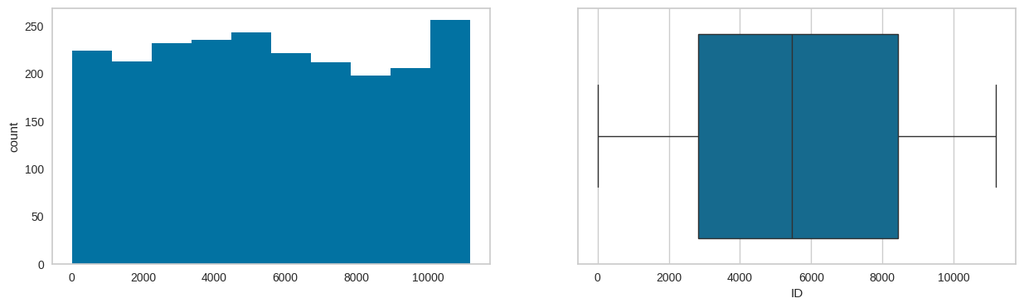

```
Year_Birth
```

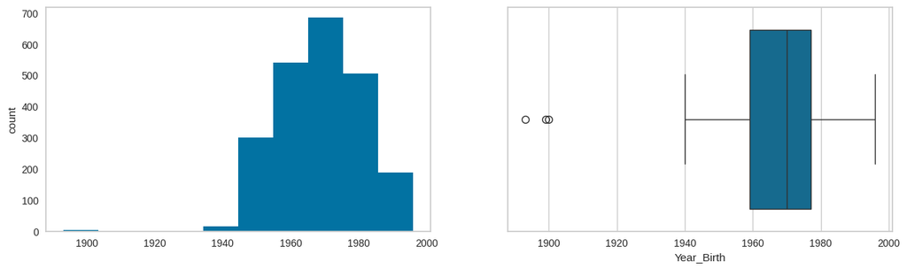

```
Education
```

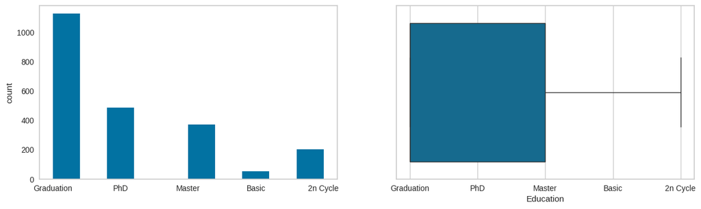

```
Marital_Status
```

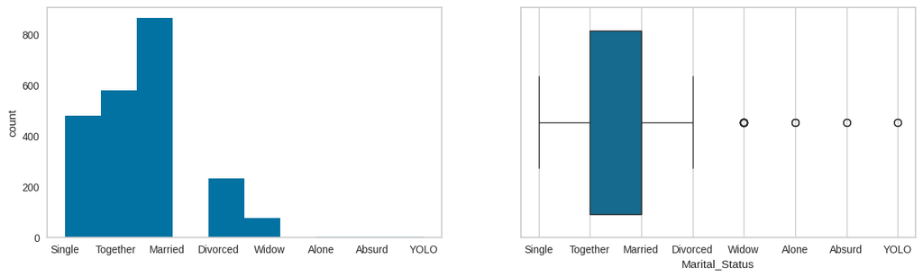

```
Income
```

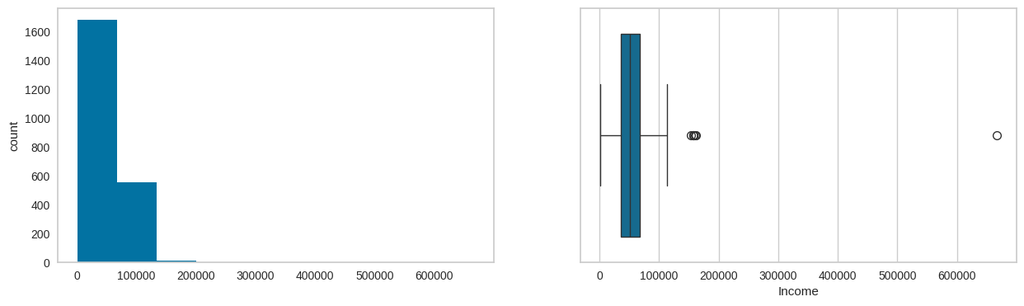

```
Kidhome
```

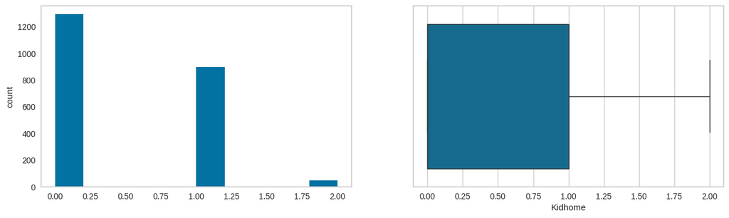

```
Teenhome
```

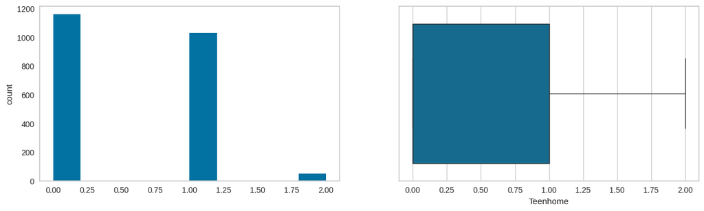

```
Dt_Customer
```

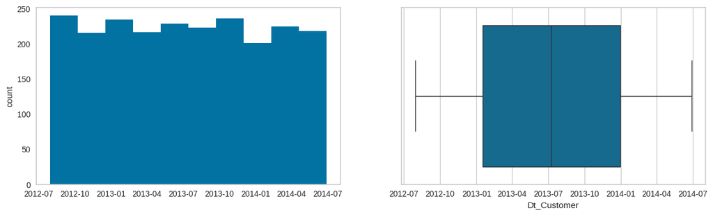

```
Recency
```

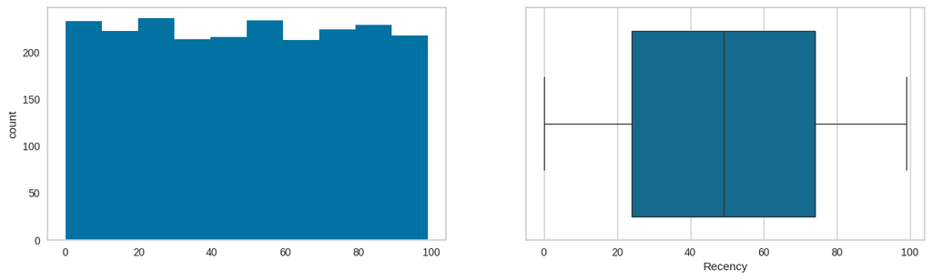

```
MntWines
```

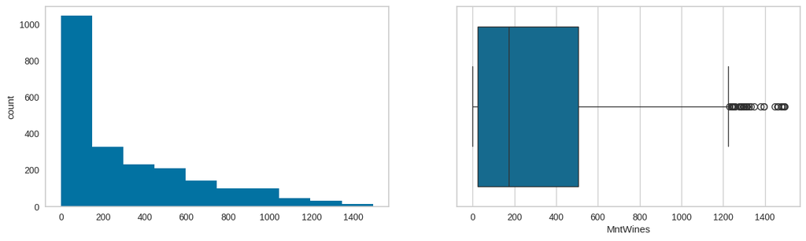

```
MntFruits
```

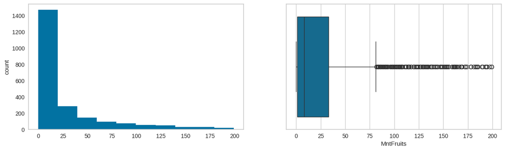

```
MntMeatProducts
```

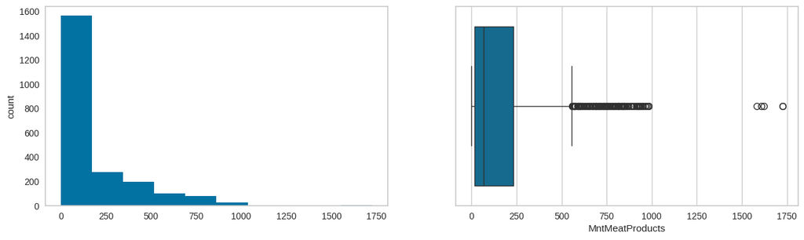

```
MntFishProducts
```

[17 more figures not shown]

```python
# Write your code here
##code to generate side-by-side histogram and boxplots for each column
for col in data_processed.columns:
    print(col)
    plt.figure(figsize=(15,4))
    plt.subplot(1,2,1)
    data_processed[col].hist(bins=10, grid=False)
    plt.ylabel('count')
    plt.subplot(1,2,2)
    sns.boxplot(x=data_processed[col])
    plt.show()
```

### Bivariate Analysis

#### **Question 6:** Perform multivariate analysis to explore the relationsips between the variables.

```python
##do more data processing to remove columns we do not need, find unique values in each column
data_processed.nunique()
```

|  | 0 |
| --- | --- |
| ID | 2240 |
| Year_Birth | 59 |
| Education | 5 |
| Marital_Status | 8 |
| Income | 1998 |
| Kidhome | 3 |
| Teenhome | 3 |
| Dt_Customer | 663 |
| Recency | 100 |
| MntWines | 776 |
| MntFruits | 158 |
| MntMeatProducts | 558 |
| MntFishProducts | 182 |
| MntSweetProducts | 177 |
| MntGoldProds | 213 |
| NumDealsPurchases | 15 |
| NumWebPurchases | 15 |
| NumCatalogPurchases | 14 |
| NumStorePurchases | 14 |
| NumWebVisitsMonth | 16 |
| AcceptedCmp3 | 2 |
| AcceptedCmp4 | 2 |
| AcceptedCmp5 | 2 |
| AcceptedCmp1 | 2 |
| AcceptedCmp2 | 2 |
| Complain | 2 |
| Z_CostContact | 1 |
| Z_Revenue | 1 |
| Response | 2 |

**dtype:** int64

Based on above results, we can drop the ID, Z_CostContact and Z_Revenue and Education plus Marital_Status(string) columns

```python
##code to to drop columns
data_processed.drop(columns = ['ID','Z_CostContact','Z_Revenue','Education', 'Marital_Status'], inplace = True)
data_processed.info()
```

```
<class 'pandas.core.frame.DataFrame'>
RangeIndex: 2240 entries, 0 to 2239
Data columns (total 24 columns):
 #   Column               Non-Null Count  Dtype
---  ------               --------------  -----
 0   Year_Birth           2240 non-null   int64
 1   Income               2240 non-null   float64
 2   Kidhome              2240 non-null   int64
 3   Teenhome             2240 non-null   int64
 4   Dt_Customer          2240 non-null   datetime64[ns]
 5   Recency              2240 non-null   int64
 6   MntWines             2240 non-null   int64
 7   MntFruits            2240 non-null   int64
 8   MntMeatProducts      2240 non-null   int64
 9   MntFishProducts      2240 non-null   int64
```

[output cut: 16 more lines]

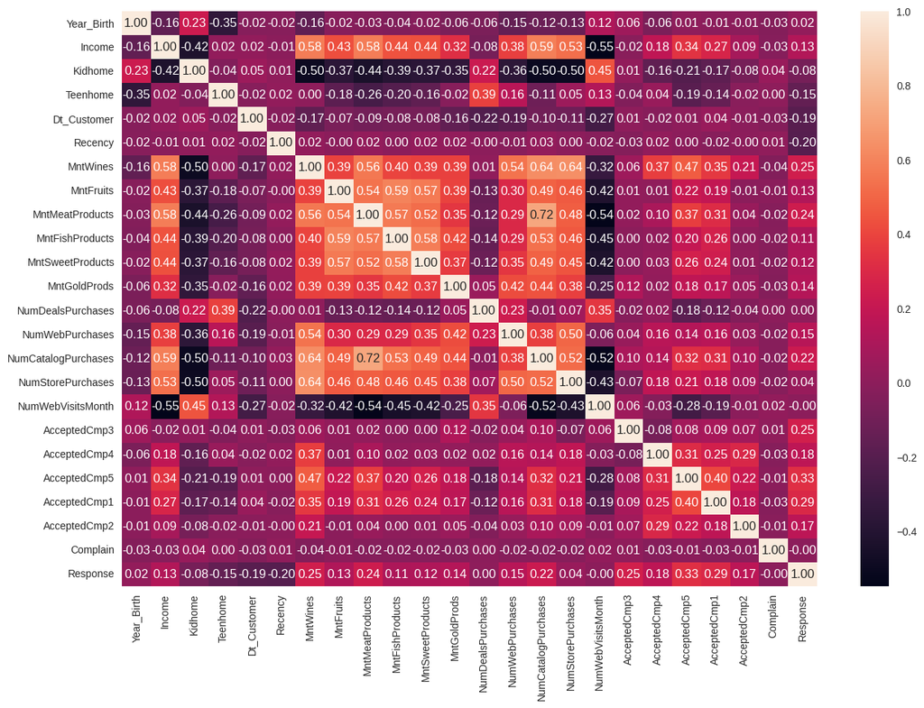

```python
# Write your code here
##create a heatmap to show correlation between all variables
plt.figure(figsize=(15,10))
sns.heatmap(data_processed.corr(), annot=True, fmt='0.2f')
plt.show()
```

##### **Observations:**

- Income is positively correlated with all spending power which makes sense because the more money one has, the more they are willing to spend.
- Number of visits to the company website in the last month is negatively correlated with income which in turn makes it negatively correlated with all spending information.
- The most positive correlation is between the amount spent on meat and number of purchases made using catalogs.
- An interesting one is the number of kids one has at home tends to negatively correlate with all spending information which might make sense because more kids probably means less of a disposable income.
- Also, perishable products like fruits, fish and meat don't tend to be bought through the website as opposed to in store. This is a contrast from gold procuts which is a lot more on par between web and store purchase.
- The spending information tend to correlate well with one another probably because customers do tend to buy items all at once.

## **K-means Clustering**

#### **Question 7** : Select the appropriate number of clusters using the elbow Plot. What do you think is the appropriate number of clusters?

```python
# Write your code here
##ran into an error because of the datetime column so I will drop this 'Dt_Customer' column first
data_processed.drop(columns = ['Dt_Customer'], inplace = True)
##scale processed data first
scaler=StandardScaler()
data_scaled=pd.DataFrame(scaler.fit_transform(data_processed), columns=data_processed.columns)
data_scaled.shape
```

```
(2240, 23)
```

```python
##view scaled data
data_scaled.head(10)
```

|  | Year_Birth | Income | Kidhome | Teenhome | Recency | MntWines | MntFruits | MntMeatProducts | MntFishProducts | MntSweetProducts | MntGoldProds | NumDealsPurchases | NumWebPurchases | NumCatalogPurchases | NumStorePurchases | NumWebVisitsMonth | AcceptedCmp3 | AcceptedCmp4 | AcceptedCmp5 | AcceptedCmp1 | AcceptedCmp2 | Complain | Response |
| --- | --- | --- | --- | --- | --- | --- | --- | --- | --- | --- | --- | --- | --- | --- | --- | --- | --- | --- | --- | --- | --- | --- | --- |
| 0 | -0.985345 | 0.237898 | -0.825218 | -0.929894 | 0.307039 | 0.983781 | 1.551577 | 1.679702 | 2.462147 | 1.476500 | 0.843207 | 0.349414 | 1.409304 | 2.510890 | -0.550785 | 0.693904 | -0.28014 | -0.28383 | -0.28014 | -0.262111 | -0.11651 | -0.097282 | 2.388846 |
| 1 | -1.235733 | -0.232151 | 1.032559 | 0.906934 | -0.383664 | -0.870479 | -0.636301 | -0.713225 | -0.650449 | -0.631503 | -0.729006 | -0.168236 | -1.110409 | -0.568720 | -1.166125 | -0.130463 | -0.28014 | -0.28383 | -0.28014 | -0.262111 | -0.11651 | -0.097282 | -0.418612 |
| 2 | -0.317643 | 0.774943 | -0.825218 | -0.929894 | -0.798086 | 0.362723 | 0.570804 | -0.177032 | 1.345274 | -0.146905 | -0.038766 | -0.685887 | 1.409304 | -0.226541 | 1.295237 | -0.542647 | -0.28014 | -0.28383 | -0.28014 | -0.262111 | -0.11651 | -0.097282 | -0.418612 |
| 3 | 1.268149 | -1.017212 | 1.032559 | -0.929894 | -0.798086 | -0.870479 | -0.560857 | -0.651187 | -0.503974 | -0.583043 | -0.748179 | -0.168236 | -0.750450 | -0.910898 | -0.550785 | 0.281720 | -0.28014 | -0.28383 | -0.28014 | -0.262111 | -0.11651 | -0.097282 | -0.418612 |
| 4 | 1.017761 | 0.244076 | 1.032559 | -0.929894 | 1.550305 | -0.389085 | 0.419916 | -0.216914 | 0.155164 | -0.001525 | -0.556446 | 1.384715 | 0.329427 | 0.115638 | 0.064556 | -0.130463 | -0.28014 | -0.28383 | -0.28014 | -0.262111 | -0.11651 | -0.097282 | -0.418612 |
| 5 | -0.150717 | 0.412263 | -0.825218 | 0.906934 | -1.143438 | 0.642051 | 0.394768 | -0.305541 | -0.687068 | 0.361924 | -0.575619 | -0.168236 | 0.689386 | 0.457817 | 1.295237 | 0.281720 | -0.28014 | -0.28383 | -0.28014 | -0.262111 | -0.11651 | -0.097282 | -0.418612 |
| 6 | 0.183134 | 0.138141 | -0.825218 | 0.906934 | -0.521805 | -0.204847 | 0.973172 | -0.013072 | 0.228401 | 0.531533 | -0.326366 | 0.867064 | 1.049345 | 0.115638 | 0.372226 | 0.281720 | -0.28014 | -0.28383 | -0.28014 | -0.262111 | -0.11651 | -0.097282 | -0.418612 |
| 7 | 1.351612 | -0.745880 | 1.032559 | -0.929894 | -0.590875 | -0.677327 | -0.409969 | -0.491658 | -0.632140 | -0.631503 | -0.403059 | -0.168236 | -0.030532 | -0.910898 | -0.550785 | 1.106087 | -0.28014 | -0.28383 | -0.28014 | -0.262111 | -0.11651 | -0.097282 | -0.418612 |
| 8 | 0.433522 | -0.869550 | 1.032559 | -0.929894 | -1.039832 | -0.861565 | -0.661449 | -0.633461 | -0.632140 | -0.583043 | -0.805699 | -0.685887 | -0.390491 | -0.910898 | -1.166125 | 1.518271 | -0.28014 | -0.28383 | -0.28014 | -0.262111 | -0.11651 | -0.097282 | 2.388846 |
| 9 | -1.569584 | -1.854085 | 1.032559 | 0.906934 | 0.652391 | -0.819963 | -0.661449 | -0.713225 | -0.668759 | -0.631503 | -0.594793 | -0.685887 | -1.110409 | -0.910898 | -1.781466 | 6.052291 | 3.56964 | -0.28383 | -0.28014 | -0.262111 | -0.11651 | -0.097282 | -0.418612 |

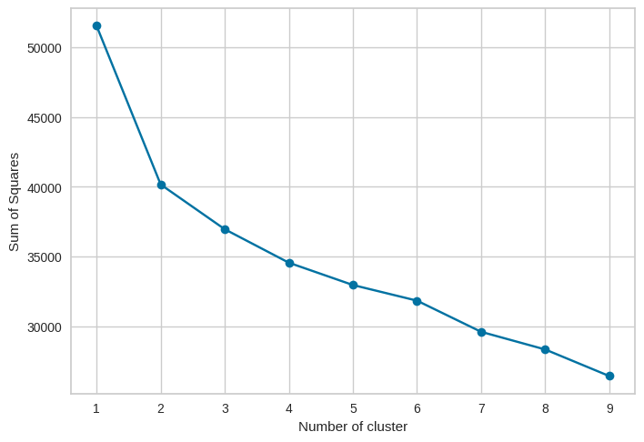

```python
##generate elbow plot
Elbow = {}

for k in range(1, 10):
    kmeans = KMeans(n_clusters=k, max_iter=1000).fit(data_scaled)
    Elbow[k] = kmeans.inertia_

# step 3
plt.figure()
plt.plot(list(Elbow.keys()), list(Elbow.values()), 'bo-')
plt.xlabel("Number of cluster")
plt.ylabel("Sum of Squares")
plt.show()
```

##### **Observations:** 2 clusters seems to be ideal based on the elbow plot.

#### **Question 8** : finalize appropriate number of clusters by checking the silhoutte score as well. Is the answer different from the elbow plot?

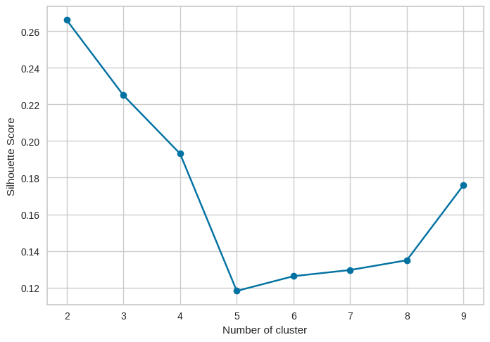

```python
# Write your code here
## code to generate silhouette score
ss = {}

for k in range(2, 10):
    kmeans = KMeans(n_clusters=k).fit(data_scaled)
    labels = kmeans.predict(data_scaled)
    ss[k] = silhouette_score(data_scaled, labels)

#plot for silhouette score
plt.figure()
plt.plot(list(ss.keys()), list(ss.values()), 'bo-')
plt.xlabel("Number of cluster")
plt.ylabel("Silhouette Score")
plt.show()
```

#### **Question 9**: Do a final fit with the appropriate number of clusters. How much total time does it take for the model to fit the data?

```python
# Write your code here
##run the k-means algorithm using cluster 2
data_scaled_copy = data_scaled
kmeans = KMeans(n_clusters=2, max_iter= 1000, random_state=1)
kmeans.fit(data_scaled)

#Adding predicted labels to the original data and scaled data
data_scaled_copy['Labels'] = kmeans.predict(data_scaled)
data['Labels'] = kmeans.predict(data_scaled)
```

```python
##check for the distribution of clusters
data.Labels.value_counts()
```

| Labels | count |
| --- | --- |
| 1 | 1351 |
| 0 | 889 |

**dtype:** int64

## **Cluster Profiling and Comparison**

#### **Question 10**: Perform cluster profiling using boxplots for the K-Means algorithm. Analyze key characteristics of each cluster and provide detailed observations.

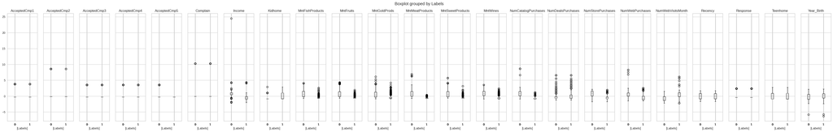

```python
# Write your code here
##create boxplots for each label
data_scaled.boxplot(by = 'Labels',layout = (1,23), figsize=(50,7))
plt.show()
```

##### **Observations:** I belive the core distribution of the company's customers can be separated into:

- Customers who earn a lot - The company should probably try to incentivize them to be in the stores as they seem to make the most purchases across all spending categories and like being in the stores anyways
- Customers who earn less - The company should try incentivizing them with online deal and discounts as they make the most use of discounts and seem to have made more use of the company's website in the last month. They also seem to usually have more kids which probably results in less 'wasteful' spending.

#### **Question 11**: Perform cluster profiling on the data using a barplot for the K-Means algorithm. Provide insights and key observations for each cluster based on the visual analysis.

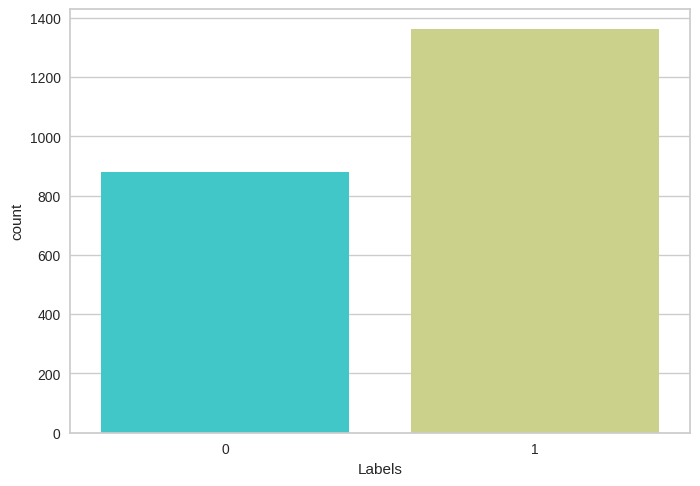

```python
# Write your code here
sns.countplot(data=data_scaled_copy, x='Labels', palette='rainbow');
plt.show()
```

##### **Observations:** Though the group that earns more contribute a lot more to the company's purchases, it is quite evident that the group earning less constitutes a larger majority of the customer base so an effort has to be made to help convert this number into more spending.

## **Business Recommedations**

#### **Question 12**: Based on the cluster insights, what business recommendations can be provided?

The company has to help the larger majortiy of its customer base that earns less to spend more by offering online deals and discounts that might be enticing enough to result in purchases as this is the group that really needs their numbers to be converted into purchases. The group that earns more has to be incentivized to be in the store and a layout that allows different items from different categories to easily be within reach will be most likely ideal within the stores. This should be ideal because they seem to make purchases regardless so making all items easily accessible from one another makes a purchase of different items that much more tempting.